# Exercise_11_BC

Betsy Cowdery

November 24, 2014

# The discrete-time exponential growth model

#### The model

```r
model{
  r~dnorm(0,.001)
  tau~dgamma(.001,.001)
  sigma~dgamma(.001,.001)

  x[1]~dnorm(0,.001)
  y[1]~dnorm(x[1],tau)

  for (i in 2:N){
    u[i]<-x[i-1] + r
    x[i]~dnorm(u[i],sigma)
    y[i]~dnorm(x[i],tau)
  }
}
```

#### Plots

1. Plots of the time series data on both the LOG and LINEAR scales that include the model mean and credible intervals.

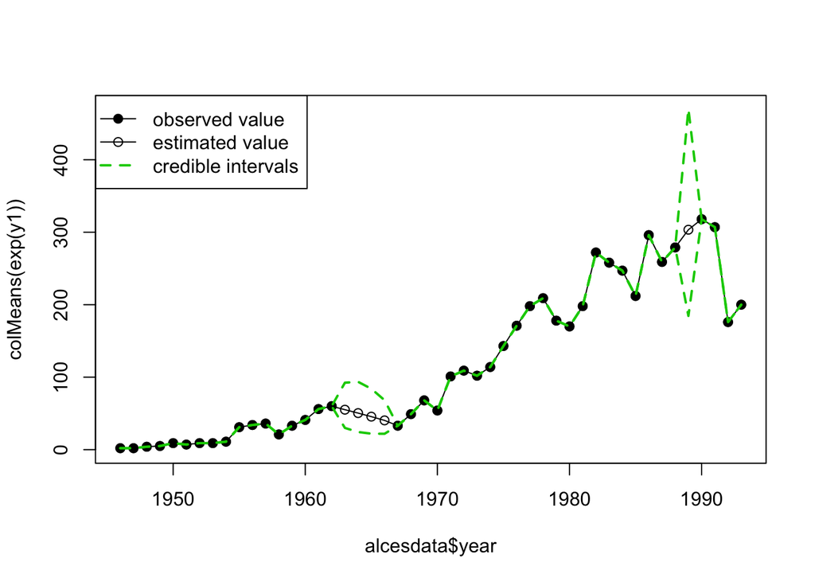

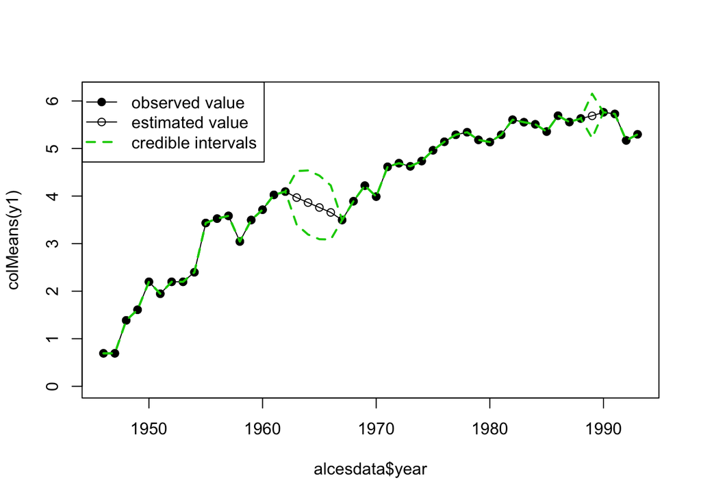

2. Density plots for the predicted values for the missing data

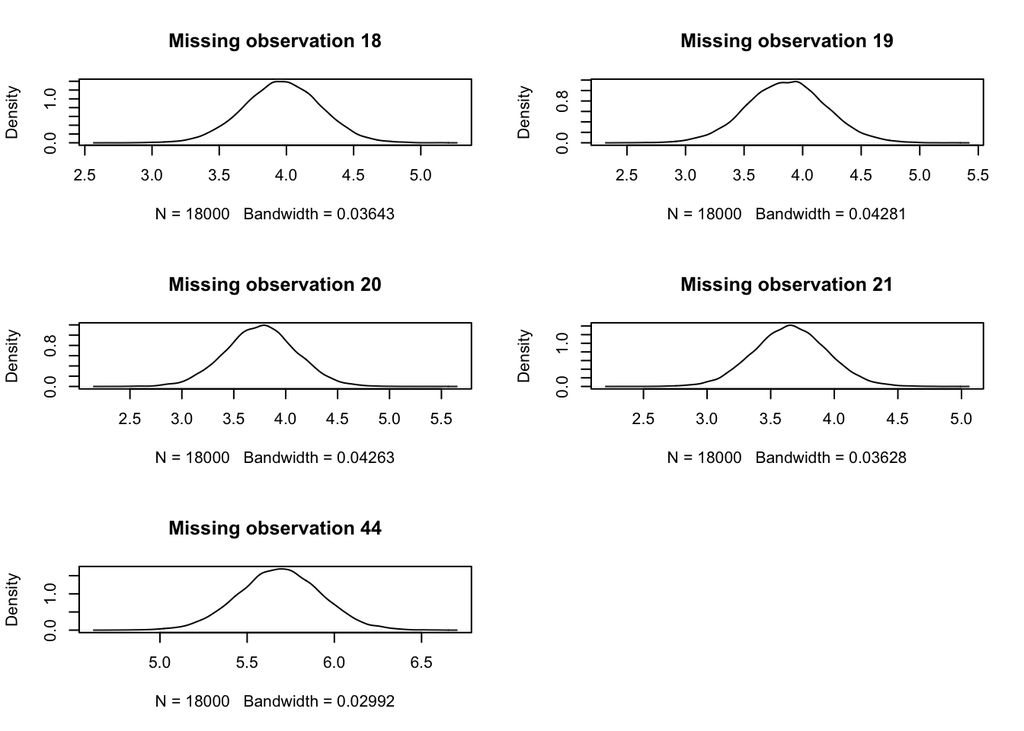

3. Density plots of the intrinsic growth rate, the observation error variance, and the process model error variance

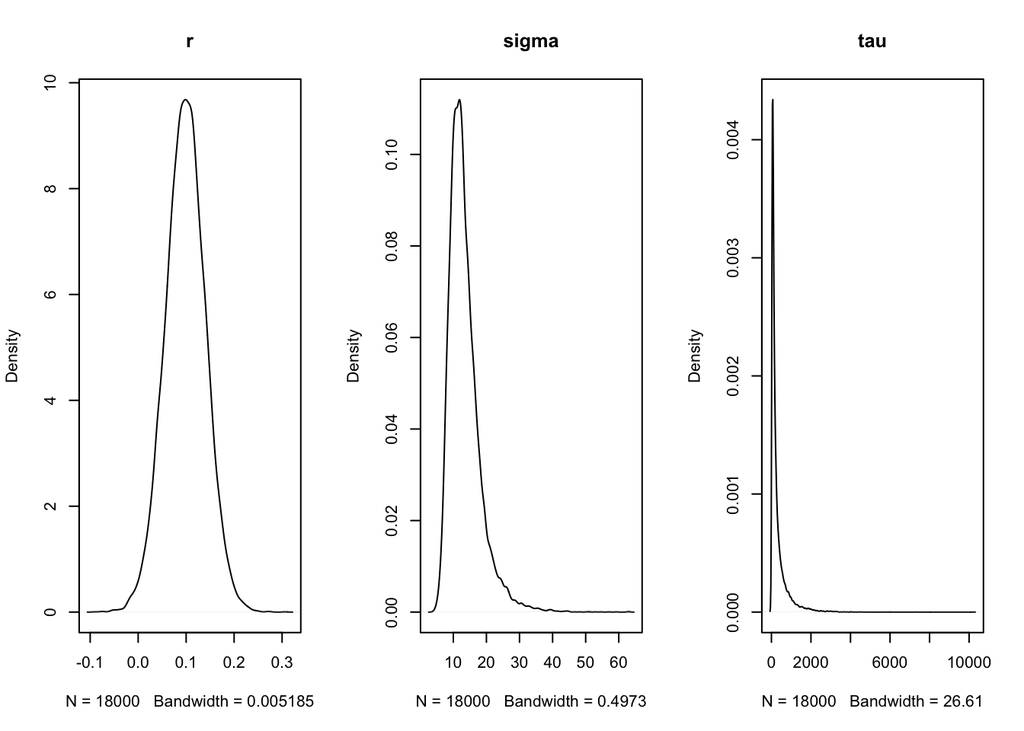

# The Ricker model (discrete-time equivalent to logistic growth)

#### The model

```r
model{

  for(i in 1:2){beta[i]~dnorm(0,.001)}
  r <- beta[1]
  K <- beta[1]/beta[2]
  tau~dgamma(.001,.001)
  sigma~dgamma(.001,.001)

  x[1]~dnorm(0,.001)
  y[1]~dnorm(x[1],tau)

  for (i in 2:N){
    u[i]<-x[i-1] + beta[1] + beta[2]*exp(x[i-1])
    x[i]~dnorm(u[i],sigma)
    y[i]~dnorm(x[i],tau)

  }
}
```

#### Plots

1. Plots of the time series data on both the LOG and LINEAR scales that include the model mean and credible intervals.

[figure not shown]

[figure not shown]

2. Density plots for the predicted values for the missing data

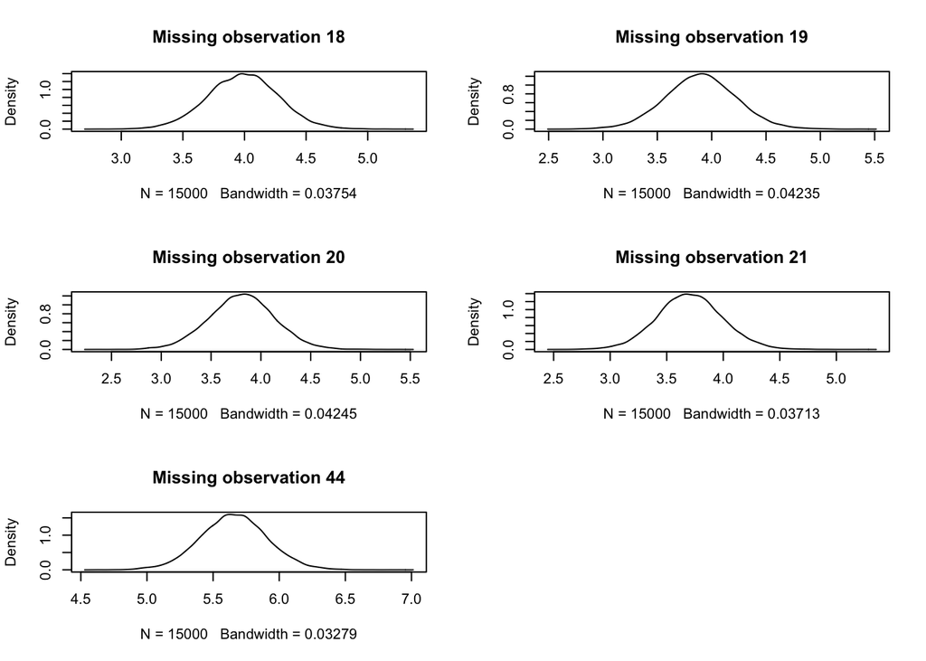

3. Density plots of the intrinsic growth rate, the observation error variance, and the process model error variance

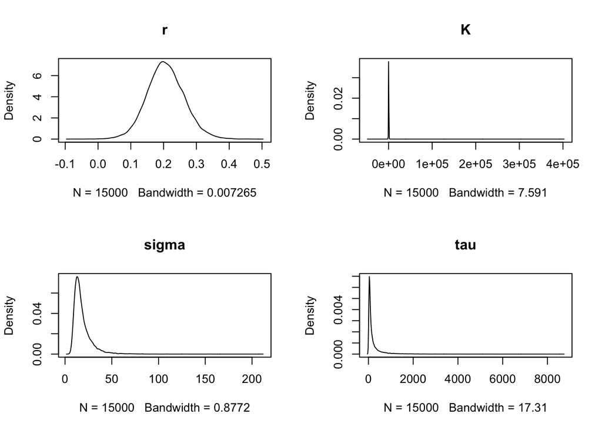

3. Construct a summary table that includes the parameters in both models, their 95% CI, and the model DIC scores.

```
##             sigma  2.5% 97.5%   tau  2.5% 97.5%       r    2.5%  97.5%
## Exponential 13.42 7.176 25.77 308.2 25.58  1620 0.09837 0.01638 0.1799
## Ricker      18.15 8.147 43.04 222.9 19.56  1318 0.20625 0.09790 0.3229
##                 K  2.5% 97.5% Mean deviance Penalized deviance
## Exponential    NA    NA    NA        -96.80              31.20
## Ricker      273.9 131.5 525.2        -79.47              55.57
```

4. Briefly give an interpretation of your results. Be sure to comment on which model is a better fit, what you can interpret about the importance of density dependence in regulating this population, and whether the population is at its carrying capacity.

We we look at the posteriors from the two models side by side, we can see that the exponential model give a more constrained estimate for both r and sigma. Ricker’s model does make have a more constrained estimate on the observation error of Y. The two models show practically no difference in their estimations of the missing values. This means that the Ricker model adds complexity without a major improvement in posteriors. Overall it appears that the exponential model is the better choice.

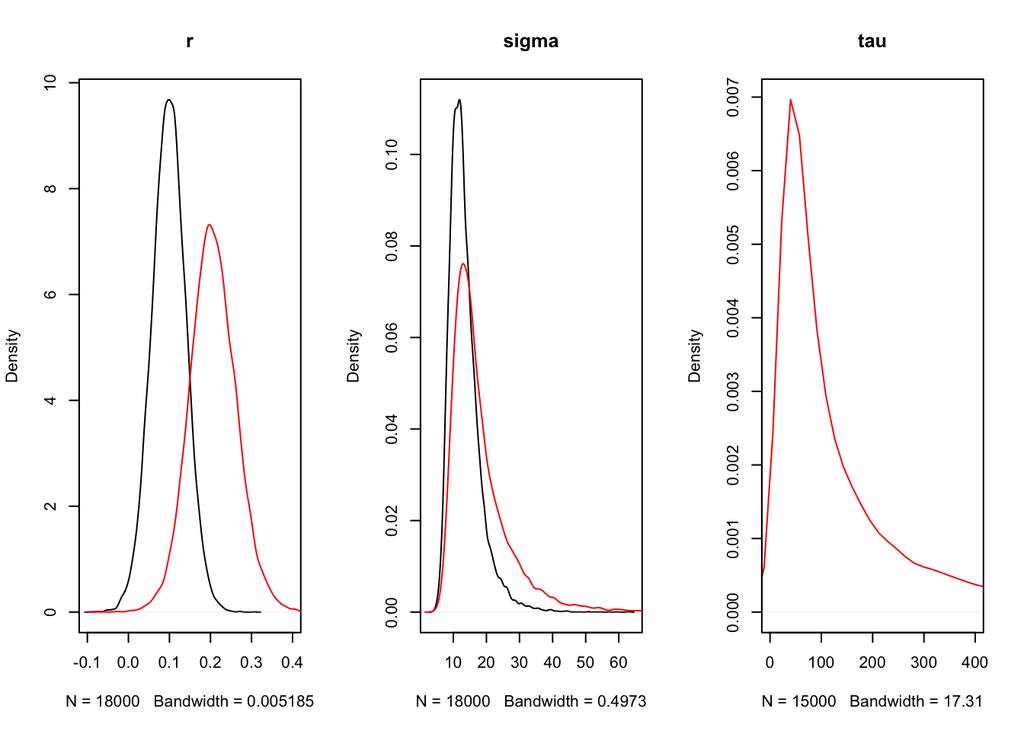

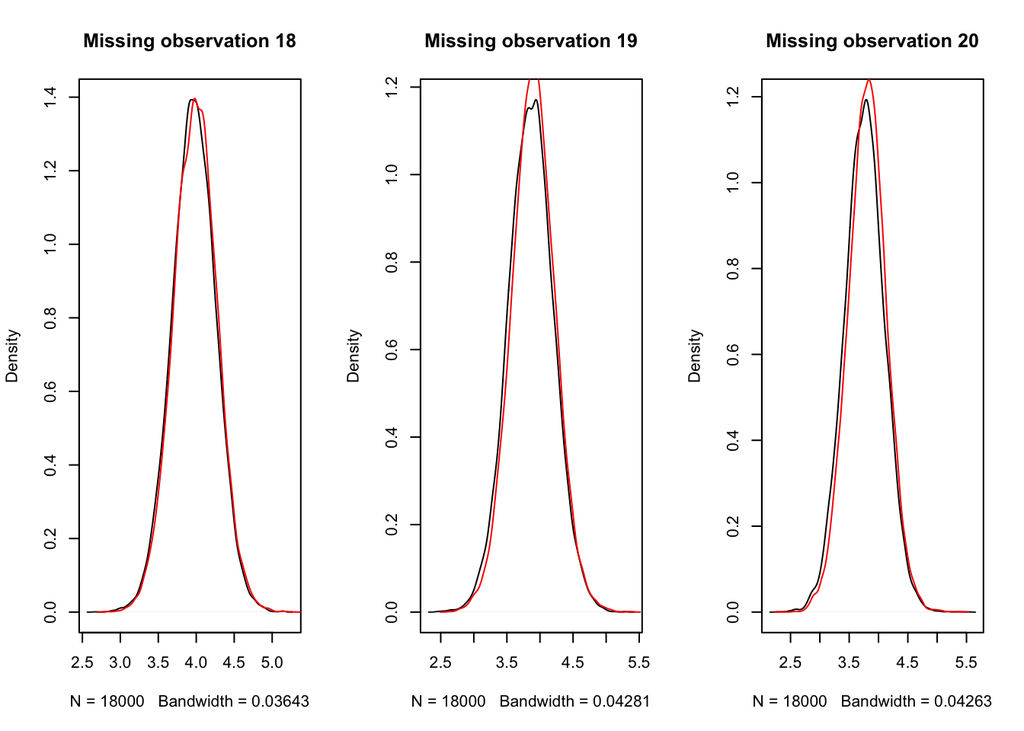

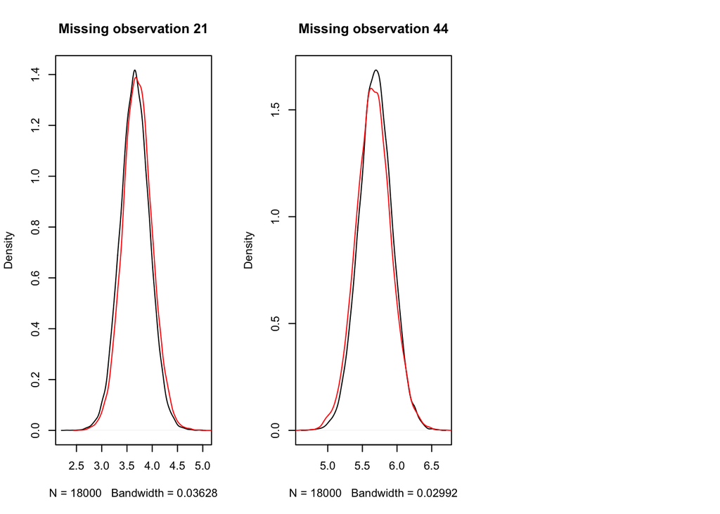

5. What can you infer about the relative importance of autogenic vs exogenous factors in regulating this population?

In this it appears that since population is not dependent on a carrying capacity and thus density, population limitation must be dependent on exogenous factors.